# Sing-energy

Tri

8/23/2021

## 1.Story

Singapore has a new milestone of becoming a zero-waste nation as government is worried about the rising number of waste disposal. At the current pace, the Semakau Landfill will run out of space by year 2035 which is an alarming situation for Singaporeans (towardszerowaste.gov.sg). Making matters worse, Singapore has limited land for building new incineration plants or landfills. The government would like to motivate citizens by sharing the total energy that the combined recycling efforts have saved every year.

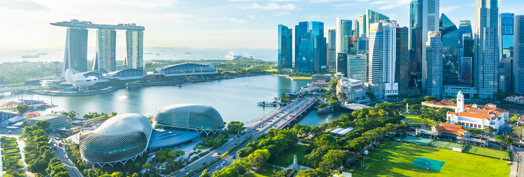

## 2.Scenario

The goal is to tranformed the data from 3 existing files into below table:

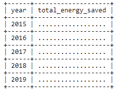

We will be using R to calculate energy saved every year from 2015 to 2019 based on five waste types: plastics, paper, glass, ferrous and non-ferrous metal.

## 3.Loading the library

```r
library(tidyverse)
library(readr)
library(dplyr)
```

## 4.Retrieve Data

The energy_saved table gives the amount of energy saved in kilowatt hour (kWh) and the amount of crude oil (barrels) by recycling 1 metric tonne (1000 kilogram) per waste type

```r
energy_saved<- read_csv('energy_saved.csv')
glimpse(energy_saved)
```

```
## Rows: 5
## Columns: 3
## $ material          <chr> "Plastic", "Glass", "Ferrous Metal", "Non-Ferrous Me~
## $ energy_saved      <chr> "5774 Kwh", "42 Kwh", "642 Kwh", "14000 Kwh", "4000 ~
## $ `crude_oil saved` <chr> "16 barrels", NA, "1.8 barrels", "40 barrels", "1.7 ~
```

the wastestats file contains Singapore’s waste from 2003 to 2017 are as below:

```r
waste_0317 <- read.csv('wastestats.csv')
glimpse(waste_0317)
```

```
## Rows: 225
## Columns: 6
## $ waste_type                  <chr> "Food", "Paper/Cardboard", "Plastics", "C&~
## $ waste_disposed_of_tonne     <int> 679900, 576000, 762700, 9700, 111500, 1191~
## $ total_waste_recycled_tonne  <dbl> 111100, 607100, 59500, 1585700, 209000, 41~
## $ total_waste_generated_tonne <int> 791000, 1183100, 822200, 1595400, 320500, ~
## $ recycling_rate              <dbl> 0.14, 0.51, 0.07, 0.99, 0.65, 0.78, 0.99, ~
## $ year                        <int> 2016, 2016, 2016, 2016, 2016, 2016, 2016, ~
```

```r
waste_1819 <- read_csv('2018_2019_waste.csv')
glimpse(waste_1819)
```

```
## Rows: 30
## Columns: 4
## $ `Waste Type`                    <chr> "Construction& Demolition", "Ferrous M~
## $ `Total Generated ('000 tonnes)` <dbl> 1440, 1278, 1011, 930, 7440, 438, 400,~
## $ `Total Recycled ('000 tonnes)`  <dbl> 1434, 1270, 449, 37, 136, 289, 293, 25~
## $ Year                            <dbl> 2019, 2019, 2019, 2019, 2019, 2019, 20~
```

## 5.Transform Data

### 5.1 Data for the year 2015 to 2017

However, we just need data from 2015 onwards, and, the waste type must be on the list, waste_0317 is transformed:

```r
waste_1517 <- waste_0317 %>%
filter(year %in% c(2015:2017))

waste_1517 <- waste_1517 %>%
  filter(waste_type %in% c('Plastic','Plastics','Ferrous metal','Glass','Non-ferrous metal','Paper/Cardboard','Non-ferrous metals'))

waste_1517 <- waste_1517%>%
  select(waste_type, year, recycled =total_waste_recycled_tonne )
```

Trim the data:

```r
waste_1517 <- waste_1517 %>%
  mutate(waste_type = str_to_lower(waste_type))

waste_1517 <- waste_1517 %>%
  mutate(waste_type = str_replace_all(waste_type,"paper/cardboard", "paper"))

waste_1517 <- waste_1517 %>%
  mutate(waste_type = str_replace_all(waste_type,'non-ferrous metals',"non-ferrous metal"))

waste_1517 <- waste_1517 %>%
  mutate(waste_type = str_replace_all(waste_type,'plastics', 'plastic'))
```

```r
waste_1517
```

```
##           waste_type year recycled
## 1              paper 2016   607100
## 2            plastic 2016    59500
## 3      ferrous metal 2016  1351500
## 4  non-ferrous metal 2016    95900
## 5              glass 2016    14700
## 6              paper 2015   603700
## 7            plastic 2015    57800
## 8      ferrous metal 2015  1333300
## 9  non-ferrous metal 2015   160400
## 10             glass 2015    14600
## 11     ferrous metal 2017  1371000
## 12 non-ferrous metal 2017    92200
## 13             paper 2017   568800
## 14             glass 2017    12400
## 15           plastic 2017    51800
```

### 5.2 Data for 2018 to 2019

Retrived columns needed for the analysis

```r
waste_1819 <-  waste_1819 %>%
  select(waste_type=`Waste Type`, year=Year, recycled=`Total Recycled ('000 tonnes)`)

waste_1819 <- waste_1819 %>%
  filter(waste_type %in% c('Glass','Paper/Cardboard','Non-Ferrous Metal','Ferrous Metal','Plastics'))
```

```r
waste_1819 <- waste_1819 %>%
  mutate(recycled = recycled * 1000)

waste_1819 <- waste_1819 %>%
  mutate(waste_type = str_to_lower(waste_type))

waste_1819 <- waste_1819 %>%
  mutate(waste_type = str_replace_all(waste_type,"paper/cardboard","paper"))

waste_1819 <- waste_1819 %>%
  mutate(waste_type = str_replace_all(waste_type,'plastics', 'plastic'))

waste_1819
```

```
## # A tibble: 10 x 3
##    waste_type         year recycled
##    <chr>             <dbl>    <dbl>
##  1 ferrous metal      2019  1270000
##  2 paper              2019   449000
##  3 plastic            2019    37000
##  4 non-ferrous metal  2019   124000
##  5 glass              2019    11000
##  6 ferrous metal      2018   126000
##  7 paper              2018   586000
##  8 plastic            2018    41000
##  9 non-ferrous metal  2018   170000
## 10 glass              2018    12000
```

### 5.3 Energy saved per material

```r
energy_saved <- energy_saved %>%
  select(material,energy_saved)

energy_saved <- energy_saved %>%
  mutate(material = str_to_lower(material)) %>%
  mutate(energy_saved = str_remove(energy_saved, 'Kwh')) %>%
  mutate(energy_saved = str_remove(energy_saved, 'kWh'))


energy_saved
```

```
## # A tibble: 5 x 2
##   material          energy_saved
##   <chr>             <chr>
## 1 plastic           "5774 "
## 2 glass             "42 "
## 3 ferrous metal     "642 "
## 4 non-ferrous metal "14000 "
## 5 paper             "4000 "
```

## 6.Join and Calculation

```r
energy_saved$energy_saved <- as.numeric(energy_saved$energy_saved)
```

```r
total_waste <-  rbind(waste_1517, waste_1819)


total_waste <- total_waste %>%
 left_join(energy_saved, by = c("waste_type"= "material"))

total_waste <- total_waste %>%
  mutate(total_recycled = energy_saved * recycled)

energy_saved_1519 <-total_waste %>%
  group_by(year) %>%
  summarise(total_energy_saved = sum(total_recycled))
```

## 7. Final Result

```r
energy_saved_1519
```

```
## # A tibble: 5 x 2
##    year total_energy_saved
##   <dbl>              <dbl>
## 1  2015         5850729000
## 2  2016         4982833400
## 3  2017         4745796000
## 4  2018         5042130000
## 5  2019         4561440000
```